# Practical Machine Learning Project

Student 11025756

June 2015

## Overview

This document summarizes the result of a machine learning analysis conducted on an data set collected as a part of the [Human Activity Recognition Project](http://groupware.les.inf.puc-rio.br/har).

## Preparation

The data set for this project was downloaded to the local file system. The [training](https://d396qusza40orc.cloudfront.net/predmachlearn/pml-training.csv) and [test sets](https://d396qusza40orc.cloudfront.net/predmachlearn/pml-testing.csv) were provided as two separate files.

Once downloaded, the training set independent variable (classe) was summarized to get an idea of the data. The same was done for the testing set.

```r
table(training$classe)
```

```
##
##    A    B    C    D    E
## 5580 3797 3422 3216 3607
```

**Training Set**  
* Number of Observations = 19622  
* Number of Columns = 160  
* Number of Observations without Omissions = 406  
**Testing Set**  
* Number of Observations = 20  
* Number of Columns = 160  
* Number of Observations without Omissions = 0

The next step was to identify and remove the zero variance predictors from the dataset. Lastly, any rows that were incomplete were removed from the training set.

```r
nsv <- nearZeroVar(training,saveMetrics=TRUE)
training <- training[,nsv$nzv==FALSE & nsv$zeroVar==FALSE]
testing <- testing[,nsv$nzv==FALSE & nsv$zeroVar==FALSE]

training <- na.omit (training)
```

Additional columns were removed that would not be useful for the overall model. For example, the timestamp and user_name were removed to focus on aspects of the data.

```r
training <- training[,-c(1:7)]
testing <- testing [,-c(1:7)]
```

Finally we create datasets for training and testing from the downloaded training data.

```r
inTrain <- createDataPartition (y=training$classe, p=0.25, list=FALSE)
trainingsubset <- training[inTrain,]
testingsubset <- training[-inTrain,]
```

## Analysis

Several models were fit to determine the best. Accuracy was used to select the optimal model using the largest value. Two models were emphasized for detailed analysis, generalized boost model (GBM) and random forest (RF). For each tuning options were evaluated to determine the best fit.

Let’s explore one each for GBM and RF model and their associated tuning parameters.

```r
### Generalized Boost Model with tuning applied
fitControl <- trainControl(method="repeatedcv", number=10, repeats=3)

modelfit1 <- train(classe ~ ., data=trainingsubset, method="gbm", trControl=fitControl,  preProcess=c("center", "scale"), verbose=FALSE)
confusionMatrix(modelfit1)
```

```
## Cross-Validated (10 fold, repeated 3 times) Confusion Matrix
##
## (entries are percentages of table totals)
##
##           Reference
## Prediction    A    B    C    D    E
##          A 18.3  4.8  5.7  3.5  1.8
##          B  1.3 10.0  0.3  2.3  3.5
##          C  2.2  2.5  9.9  2.2  1.0
##          D  4.8  1.9  1.2  7.3  1.3
##          E  0.3  0.0  0.0  1.9 11.6
```

```r
modelfit1$finalModel
```

```
## A gradient boosted model with multinomial loss function.
## 150 iterations were performed.
## There were 92 predictors of which 87 had non-zero influence.
```

```r
getTrainPerf(modelfit1)
```

```
##   TrainAccuracy TrainKappa method
## 1     0.5715152  0.4527465    gbm
```

```r
## Random Forest with tuning applied
modelfitrftest1 <- train(classe ~ ., data = trainingsubset, preProcess=c("center", "scale"), method="rf", trControl=fitControl)
getTrainPerf(modelfitrftest1)
```

```
##   TrainAccuracy TrainKappa method
## 1     0.6220202  0.5195821     rf
```

```r
fitControl2 <- trainControl(method="oob", number=10, repeats=3)
modelfit2 <- train(classe ~ ., data = trainingsubset, preProcess=c("center", "scale"), method="rf", trControl=fitControl2)
modelfit2$finalModel
```

```
##
## Call:
##  randomForest(x = x, y = y, mtry = param$mtry)
##                Type of random forest: classification
##                      Number of trees: 500
## No. of variables tried at each split: 47
##
##         OOB estimate of  error rate: 40.38%
## Confusion matrix:
##    A  B  C D  E class.error
## A 15  3  7 3  0   0.4642857
## B  4 13  2 1  0   0.3500000
## C  7  0 11 0  0   0.3888889
## D  5  1  1 9  2   0.5000000
## E  2  3  0 1 14   0.3000000
```

```r
getTrainPerf(modelfit2)
```

```
##   TrainAccuracy TrainKappa method
## 1     0.6346154  0.5357143     rf
```

Now we will evaluate both model types without any tuning.

```r
### Generalized Boost Model w/o tuning
modelfit1a <- train(classe ~ ., data=trainingsubset, method="gbm", verbose=FALSE)
confusionMatrix(modelfit1a)
```

```
## Bootstrapped (25 reps) Confusion Matrix
##
## (entries are percentages of table totals)
##
##           Reference
## Prediction    A    B    C    D    E
##          A 14.5  5.2  3.9  3.8  2.6
##          B  2.8  7.5  0.8  1.8  3.2
##          C  3.6  1.3  9.8  3.6  1.0
##          D  5.2  3.4  1.8  6.1  1.2
##          E  2.3  0.6  0.3  2.1 11.5
```

```r
modelfit1a$finalModel
```

```
## A gradient boosted model with multinomial loss function.
## 100 iterations were performed.
## There were 92 predictors of which 69 had non-zero influence.
```

```r
getTrainPerf(modelfit1a)
```

```
##   TrainAccuracy TrainKappa method
## 1     0.4949177  0.3649501    gbm
```

```r
### Random Forest w/o tuning
modelfit2a <- train(classe ~ ., data = trainingsubset, method="rf")
confusionMatrix(modelfit2a)
```

```
## Bootstrapped (25 reps) Confusion Matrix
##
## (entries are percentages of table totals)
##
##           Reference
## Prediction    A    B    C    D    E
##          A 15.1  4.9  8.2  5.2  1.4
##          B  2.6 10.1  0.0  1.4  3.1
##          C  4.3  1.4  7.7  2.1  0.7
##          D  4.5  2.3  0.8  6.9  1.0
##          E  1.0  0.8  0.4  2.7 11.6
```

```r
modelfit2a$finalModel
```

```
##
## Call:
##  randomForest(x = x, y = y, mtry = param$mtry)
##                Type of random forest: classification
##                      Number of trees: 500
## No. of variables tried at each split: 47
##
##         OOB estimate of  error rate: 37.5%
## Confusion matrix:
##    A  B  C D  E class.error
## A 17  3  4 3  1   0.3928571
## B  5 13  1 1  0   0.3500000
## C  7  0 11 0  0   0.3888889
## D  5  1  1 9  2   0.5000000
## E  2  2  0 1 15   0.2500000
```

```r
getTrainPerf(modelfit2a)
```

```
##   TrainAccuracy TrainKappa method
## 1     0.5132413  0.3845927     rf
```

## Training Results

The Appendix contains the accuracy plots for each of the models prepared in the analysis section. In each case, tuning did improve the accuracy for each model. Based upon the findings of training, the tuned RF model outperforms the tuned GBM model. Next we’ll take a look at the testing sample to see how well each model can predict.

## Prediction

Lastly, we will show the predictive outcomes associated with each model.

```r
### GBM Models
confusionMatrix (data=pred1, testingsubset$class)
```

```
## Confusion Matrix and Statistics
##
##           Reference
## Prediction  A  B  C  D  E
##          A 63 14 15  7  3
##          B  3 32  4  4  5
##          C  8  6 28  9  1
##          D  7  3  5 24  4
##          E  0  4  0  7 46
##
## Overall Statistics
##
##                Accuracy : 0.6391
##                  95% CI : (0.5821, 0.6933)
##     No Information Rate : 0.2682
##     P-Value [Acc > NIR] : <2e-16
##
##                   Kappa : 0.5419
##  Mcnemar's Test P-Value : 0.1036
##
## Statistics by Class:
##
##                      Class: A Class: B Class: C Class: D Class: E
## Sensitivity            0.7778   0.5424  0.53846  0.47059   0.7797
## Specificity            0.8235   0.9342  0.90400  0.92430   0.9547
## Pos Pred Value         0.6176   0.6667  0.53846  0.55814   0.8070
## Neg Pred Value         0.9100   0.8937  0.90400  0.89575   0.9469
## Prevalence             0.2682   0.1954  0.17219  0.16887   0.1954
## Detection Rate         0.2086   0.1060  0.09272  0.07947   0.1523
## Detection Prevalence   0.3377   0.1589  0.17219  0.14238   0.1887
## Balanced Accuracy      0.8007   0.7383  0.72123  0.69745   0.8672
```

```r
confusionMatrix (data=pred1a, testingsubset$class)
```

```
## Confusion Matrix and Statistics
##
##           Reference
## Prediction  A  B  C  D  E
##          A 63 11 15  5  2
##          B  2 33  5  2  6
##          C  5  0 27  8  1
##          D 11  9  4 27  4
##          E  0  6  1  9 46
##
## Overall Statistics
##
##                Accuracy : 0.649
##                  95% CI : (0.5923, 0.7028)
##     No Information Rate : 0.2682
##     P-Value [Acc > NIR] : < 2.2e-16
##
##                   Kappa : 0.5554
##  Mcnemar's Test P-Value : 0.001682
##
## Statistics by Class:
##
##                      Class: A Class: B Class: C Class: D Class: E
## Sensitivity            0.7778   0.5593   0.5192   0.5294   0.7797
## Specificity            0.8507   0.9383   0.9440   0.8884   0.9342
## Pos Pred Value         0.6562   0.6875   0.6585   0.4909   0.7419
## Neg Pred Value         0.9126   0.8976   0.9042   0.9028   0.9458
## Prevalence             0.2682   0.1954   0.1722   0.1689   0.1954
## Detection Rate         0.2086   0.1093   0.0894   0.0894   0.1523
## Detection Prevalence   0.3179   0.1589   0.1358   0.1821   0.2053
## Balanced Accuracy      0.8142   0.7488   0.7316   0.7089   0.8569
```

```r
### RF Models
confusionMatrix (data=pred2, testingsubset$class)
```

```
## Confusion Matrix and Statistics
##
##           Reference
## Prediction  A  B  C  D  E
##          A 65 15 16  2  3
##          B  5 35  4  1 10
##          C  6  3 31  8  3
##          D  5  5  1 35  1
##          E  0  1  0  5 42
##
## Overall Statistics
##
##                Accuracy : 0.6887
##                  95% CI : (0.6332, 0.7405)
##     No Information Rate : 0.2682
##     P-Value [Acc > NIR] : < 2.2e-16
##
##                   Kappa : 0.6052
##  Mcnemar's Test P-Value : 0.0001193
##
## Statistics by Class:
##
##                      Class: A Class: B Class: C Class: D Class: E
## Sensitivity            0.8025   0.5932   0.5962   0.6863   0.7119
## Specificity            0.8371   0.9177   0.9200   0.9522   0.9753
## Pos Pred Value         0.6436   0.6364   0.6078   0.7447   0.8750
## Neg Pred Value         0.9204   0.9028   0.9163   0.9373   0.9331
## Prevalence             0.2682   0.1954   0.1722   0.1689   0.1954
## Detection Rate         0.2152   0.1159   0.1026   0.1159   0.1391
## Detection Prevalence   0.3344   0.1821   0.1689   0.1556   0.1589
## Balanced Accuracy      0.8198   0.7555   0.7581   0.8192   0.8436
```

```r
confusionMatrix (data=pred2a, testingsubset$class)
```

```
## Confusion Matrix and Statistics
##
##           Reference
## Prediction  A  B  C  D  E
##          A 64 15 18  3  3
##          B  5 34  4  1 10
##          C  6  4 30  8  3
##          D  6  5  0 34  1
##          E  0  1  0  5 42
##
## Overall Statistics
##
##                Accuracy : 0.6755
##                  95% CI : (0.6195, 0.728)
##     No Information Rate : 0.2682
##     P-Value [Acc > NIR] : < 2.2e-16
##
##                   Kappa : 0.5881
##  Mcnemar's Test P-Value : 2.868e-05
##
## Statistics by Class:
##
##                      Class: A Class: B Class: C Class: D Class: E
## Sensitivity            0.7901   0.5763  0.57692   0.6667   0.7119
## Specificity            0.8235   0.9177  0.91600   0.9522   0.9753
## Pos Pred Value         0.6214   0.6296  0.58824   0.7391   0.8750
## Neg Pred Value         0.9146   0.8992  0.91235   0.9336   0.9331
## Prevalence             0.2682   0.1954  0.17219   0.1689   0.1954
## Detection Rate         0.2119   0.1126  0.09934   0.1126   0.1391
## Detection Prevalence   0.3411   0.1788  0.16887   0.1523   0.1589
## Balanced Accuracy      0.8068   0.7470  0.74646   0.8094   0.8436
```

## Appendix

Additional plots for analysis are included here.

[figure not shown]

```r
plot (modelfit1, Main="GBM with Tuning")
```

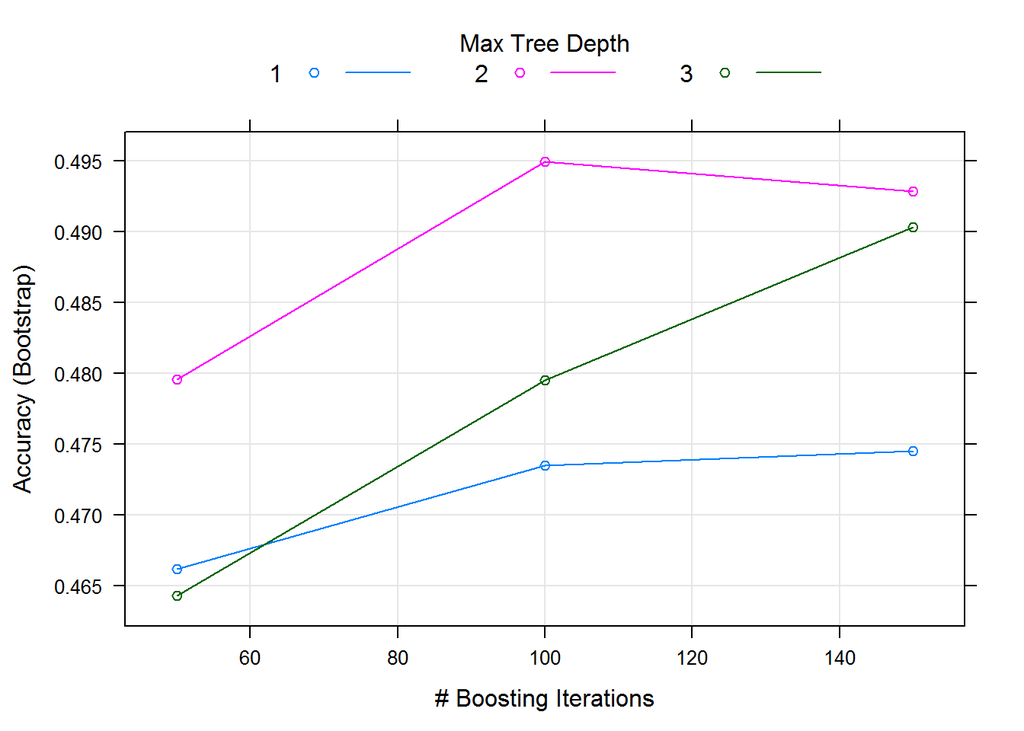

```r
plot (modelfit1a, Main="GBM without Tuning")
```

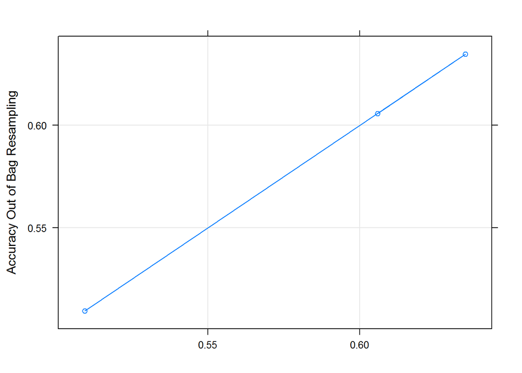

```r
plot (modelfit2, Main="RF with Tuning")
```

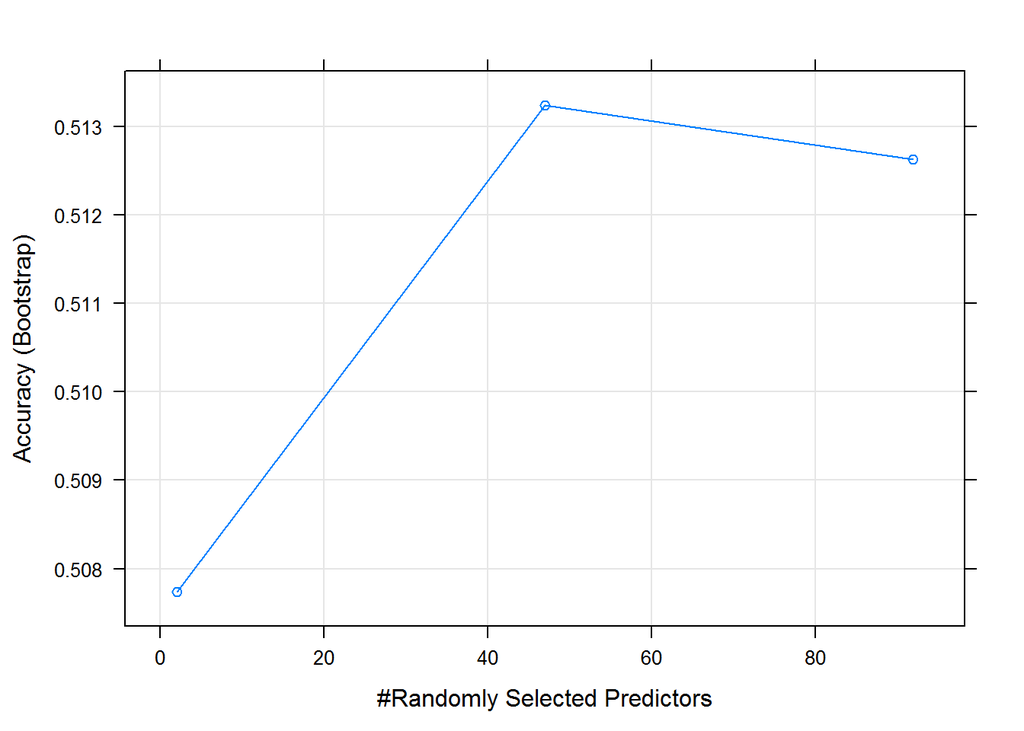

```r
plot (modelfit2a, Main="RF without Tuning")
```